# Risk Factor Analysis

## Outcome Variable

**Outcome Variable:** ever_stunted

## Predictor Variables

**Intervention Variable:** mwtkg

**Adjustment Set:**

unadjusted

## Stratifying Variables

The analysis was stratified on these variable(s):

- agecat
- studyid

The following strata were considered:

- agecat: 12 months, studyid: ki1000304b-SAS-CompFeed
- agecat: 12 months, studyid: ki1017093-NIH-Birth
- agecat: 12 months, studyid: ki1017093c-NIH-Crypto
- agecat: 12 months, studyid: ki1066203-TanzaniaChild2
- agecat: 12 months, studyid: ki1119695-PROBIT
- agecat: 12 months, studyid: ki1126311-ZVITAMBO
- agecat: 12 months, studyid: ki1148112-LCNI-5
- agecat: 12 months, studyid: kiGH5241-JiVitA-3
- agecat: 18 months, studyid: ki1000304b-SAS-CompFeed
- agecat: 18 months, studyid: ki1017093-NIH-Birth
- agecat: 18 months, studyid: ki1017093c-NIH-Crypto
- agecat: 18 months, studyid: ki1066203-TanzaniaChild2
- agecat: 18 months, studyid: ki1119695-PROBIT
- agecat: 18 months, studyid: ki1126311-ZVITAMBO
- agecat: 18 months, studyid: ki1148112-LCNI-5
- agecat: 18 months, studyid: kiGH5241-JiVitA-3
- agecat: 24 months, studyid: ki1000304b-SAS-CompFeed
- agecat: 24 months, studyid: ki1017093-NIH-Birth
- agecat: 24 months, studyid: ki1017093c-NIH-Crypto
- agecat: 24 months, studyid: ki1066203-TanzaniaChild2
- agecat: 24 months, studyid: ki1119695-PROBIT
- agecat: 24 months, studyid: ki1126311-ZVITAMBO
- agecat: 24 months, studyid: ki1148112-LCNI-5
- agecat: 24 months, studyid: kiGH5241-JiVitA-3
- agecat: 3 months, studyid: ki1000304b-SAS-CompFeed
- agecat: 3 months, studyid: ki1017093-NIH-Birth
- agecat: 3 months, studyid: ki1017093c-NIH-Crypto
- agecat: 3 months, studyid: ki1066203-TanzaniaChild2
- agecat: 3 months, studyid: ki1119695-PROBIT
- agecat: 3 months, studyid: ki1126311-ZVITAMBO
- agecat: 3 months, studyid: kiGH5241-JiVitA-3
- agecat: 6 months, studyid: ki1000304b-SAS-CompFeed
- agecat: 6 months, studyid: ki1017093-NIH-Birth
- agecat: 6 months, studyid: ki1017093c-NIH-Crypto
- agecat: 6 months, studyid: ki1066203-TanzaniaChild2
- agecat: 6 months, studyid: ki1119695-PROBIT
- agecat: 6 months, studyid: ki1126311-ZVITAMBO
- agecat: 6 months, studyid: ki1148112-LCNI-5
- agecat: 6 months, studyid: kiGH5241-JiVitA-3

### Dropped Strata

Some strata were dropped due to rare outcomes:

## Methods Detail

# Results Detail

## Results Plots

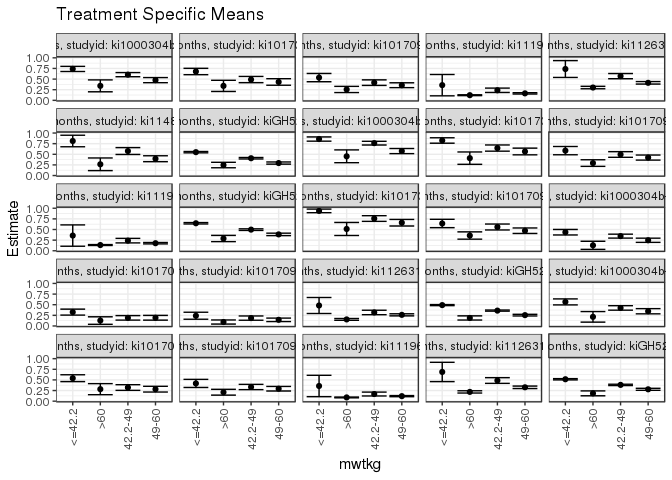

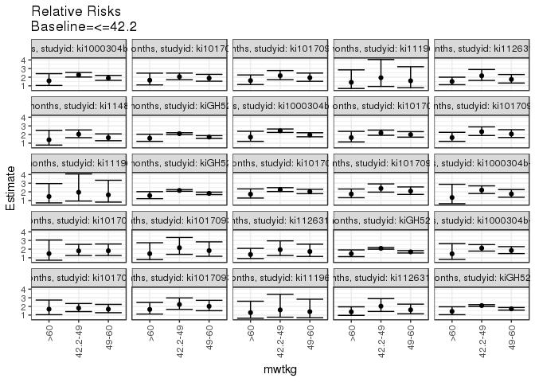

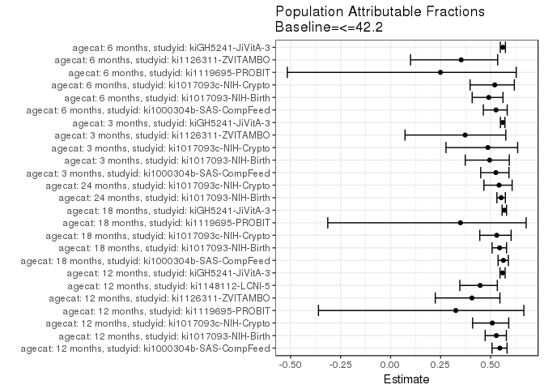

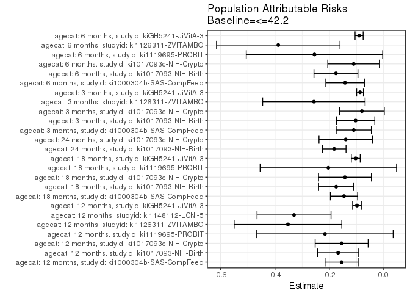

## Data Summary

| agecat | studyid | A | n | nA | nAY0 | nAY1 |
| --- | --- | --- | --- | --- | --- | --- |
| 12 months | ki1000304b-SAS-CompFeed | <=42.2 | 887 | 203 | 53 | 150 |
| 12 months | ki1000304b-SAS-CompFeed | >60 | 887 | 44 | 29 | 15 |
| 12 months | ki1000304b-SAS-CompFeed | 42.2-49 | 887 | 379 | 150 | 229 |
| 12 months | ki1000304b-SAS-CompFeed | 49-60 | 887 | 261 | 137 | 124 |
| 12 months | ki1017093-NIH-Birth | <=42.2 | 541 | 149 | 48 | 101 |
| 12 months | ki1017093-NIH-Birth | >60 | 541 | 50 | 33 | 17 |
| 12 months | ki1017093-NIH-Birth | 42.2-49 | 541 | 180 | 92 | 88 |
| 12 months | ki1017093-NIH-Birth | 49-60 | 541 | 162 | 92 | 70 |
| 12 months | ki1017093c-NIH-Crypto | <=42.2 | 729 | 101 | 47 | 54 |
| 12 months | ki1017093c-NIH-Crypto | >60 | 729 | 137 | 102 | 35 |
| 12 months | ki1017093c-NIH-Crypto | 42.2-49 | 729 | 221 | 129 | 92 |
| 12 months | ki1017093c-NIH-Crypto | 49-60 | 729 | 270 | 174 | 96 |
| 12 months | ki1066203-TanzaniaChild2 | <=42.2 | 488 | 5 | 2 | 3 |
| 12 months | ki1066203-TanzaniaChild2 | >60 | 488 | 227 | 167 | 60 |
| 12 months | ki1066203-TanzaniaChild2 | 42.2-49 | 488 | 43 | 26 | 17 |
| 12 months | ki1066203-TanzaniaChild2 | 49-60 | 488 | 213 | 135 | 78 |
| 12 months | ki1119695-PROBIT | <=42.2 | 6687 | 14 | 9 | 5 |
| 12 months | ki1119695-PROBIT | >60 | 6687 | 4093 | 3597 | 496 |
| 12 months | ki1119695-PROBIT | 42.2-49 | 6687 | 262 | 200 | 62 |
| 12 months | ki1119695-PROBIT | 49-60 | 6687 | 2318 | 1938 | 380 |
| 12 months | ki1126311-ZVITAMBO | <=42.2 | 2335 | 19 | 5 | 14 |
| 12 months | ki1126311-ZVITAMBO | >60 | 2335 | 990 | 692 | 298 |
| 12 months | ki1126311-ZVITAMBO | 42.2-49 | 2335 | 253 | 109 | 144 |
| 12 months | ki1126311-ZVITAMBO | 49-60 | 2335 | 1073 | 631 | 442 |
| 12 months | ki1148112-LCNI-5 | <=42.2 | 402 | 32 | 6 | 26 |
| 12 months | ki1148112-LCNI-5 | >60 | 402 | 34 | 25 | 9 |
| 12 months | ki1148112-LCNI-5 | 42.2-49 | 402 | 144 | 61 | 83 |
| 12 months | ki1148112-LCNI-5 | 49-60 | 402 | 192 | 116 | 76 |
| 12 months | kiGH5241-JiVitA-3 | <=42.2 | 8367 | 3796 | 1708 | 2088 |
| 12 months | kiGH5241-JiVitA-3 | >60 | 8367 | 174 | 131 | 43 |

[output cut: 130 more lines]

## Results Table

### Parameter: TSM

| agecat | studyid | intervention_level | baseline_level | estimate | ci_lower | ci_upper |
| --- | --- | --- | --- | --- | --- | --- |
| 12 months | ki1000304b-SAS-CompFeed | <=42.2 | NA | 0.7389163 | 0.6784612 | 0.7993713 |
| 12 months | ki1000304b-SAS-CompFeed | >60 | NA | 0.3409091 | 0.2007702 | 0.4810480 |
| 12 months | ki1000304b-SAS-CompFeed | 42.2-49 | NA | 0.6042216 | 0.5549613 | 0.6534820 |
| 12 months | ki1000304b-SAS-CompFeed | 49-60 | NA | 0.4750958 | 0.4144775 | 0.5357140 |
| 12 months | ki1017093-NIH-Birth | <=42.2 | NA | 0.6778523 | 0.6027503 | 0.7529544 |
| 12 months | ki1017093-NIH-Birth | >60 | NA | 0.3400000 | 0.2085755 | 0.4714245 |
| 12 months | ki1017093-NIH-Birth | 42.2-49 | NA | 0.4888889 | 0.4157958 | 0.5619820 |
| 12 months | ki1017093-NIH-Birth | 49-60 | NA | 0.4320988 | 0.3557468 | 0.5084507 |
| 12 months | ki1017093c-NIH-Crypto | <=42.2 | NA | 0.5346535 | 0.4373093 | 0.6319976 |
| 12 months | ki1017093c-NIH-Crypto | >60 | NA | 0.2554745 | 0.1823943 | 0.3285546 |
| 12 months | ki1017093c-NIH-Crypto | 42.2-49 | NA | 0.4162896 | 0.3512547 | 0.4813245 |
| 12 months | ki1017093c-NIH-Crypto | 49-60 | NA | 0.3555556 | 0.2984194 | 0.4126917 |
| 12 months | ki1119695-PROBIT | <=42.2 | NA | 0.3571429 | 0.1061307 | 0.6081550 |
| 12 months | ki1119695-PROBIT | >60 | NA | 0.1211825 | 0.1111841 | 0.1311809 |
| 12 months | ki1119695-PROBIT | 42.2-49 | NA | 0.2366412 | 0.1851730 | 0.2881095 |
| 12 months | ki1119695-PROBIT | 49-60 | NA | 0.1639344 | 0.1488621 | 0.1790067 |
| 12 months | ki1126311-ZVITAMBO | <=42.2 | NA | 0.7368421 | 0.5387990 | 0.9348852 |
| 12 months | ki1126311-ZVITAMBO | >60 | NA | 0.3010101 | 0.2724309 | 0.3295893 |
| 12 months | ki1126311-ZVITAMBO | 42.2-49 | NA | 0.5691700 | 0.5081384 | 0.6302016 |
| 12 months | ki1126311-ZVITAMBO | 49-60 | NA | 0.4119292 | 0.3824736 | 0.4413847 |
| 12 months | ki1148112-LCNI-5 | <=42.2 | NA | 0.8125000 | 0.6770976 | 0.9479024 |
| 12 months | ki1148112-LCNI-5 | >60 | NA | 0.2647059 | 0.1162280 | 0.4131838 |
| 12 months | ki1148112-LCNI-5 | 42.2-49 | NA | 0.5763889 | 0.4955819 | 0.6571959 |
| 12 months | ki1148112-LCNI-5 | 49-60 | NA | 0.3958333 | 0.3265749 | 0.4650918 |
| 12 months | kiGH5241-JiVitA-3 | <=42.2 | NA | 0.5500527 | 0.5342259 | 0.5658795 |
| 12 months | kiGH5241-JiVitA-3 | >60 | NA | 0.2471264 | 0.1830320 | 0.3112208 |
| 12 months | kiGH5241-JiVitA-3 | 42.2-49 | NA | 0.4071247 | 0.3899504 | 0.4242989 |
| 12 months | kiGH5241-JiVitA-3 | 49-60 | NA | 0.2936951 | 0.2684753 | 0.3189150 |
| 18 months | ki1000304b-SAS-CompFeed | <=42.2 | NA | 0.8586387 | 0.8092013 | 0.9080761 |
| 18 months | ki1000304b-SAS-CompFeed | >60 | NA | 0.4523810 | 0.3017658 | 0.6029961 |

[output cut: 70 more lines]

### Parameter: E(Y)

| agecat | studyid | intervention_level | baseline_level | estimate | ci_lower | ci_upper |
| --- | --- | --- | --- | --- | --- | --- |
| 12 months | ki1000304b-SAS-CompFeed | NA | NA | 0.5839910 | 0.5767514 | 0.5912306 |
| 12 months | ki1017093-NIH-Birth | NA | NA | 0.5101664 | 0.5007757 | 0.5195570 |
| 12 months | ki1017093c-NIH-Crypto | NA | NA | 0.3799726 | 0.3739612 | 0.3859840 |
| 12 months | ki1119695-PROBIT | NA | NA | 0.1410199 | 0.1403093 | 0.1417305 |
| 12 months | ki1126311-ZVITAMBO | NA | NA | 0.3845824 | 0.3809524 | 0.3882125 |
| 12 months | ki1148112-LCNI-5 | NA | NA | 0.4825871 | 0.4689455 | 0.4962286 |
| 12 months | kiGH5241-JiVitA-3 | NA | NA | 0.4516553 | 0.4495401 | 0.4537706 |
| 18 months | ki1000304b-SAS-CompFeed | NA | NA | 0.7126168 | 0.7044763 | 0.7207574 |
| 18 months | ki1017093-NIH-Birth | NA | NA | 0.6498994 | 0.6388599 | 0.6609389 |
| 18 months | ki1017093c-NIH-Crypto | NA | NA | 0.4433566 | 0.4368005 | 0.4499128 |
| 18 months | ki1119695-PROBIT | NA | NA | 0.1534475 | 0.1527559 | 0.1541390 |
| 18 months | kiGH5241-JiVitA-3 | NA | NA | 0.5437543 | 0.5413860 | 0.5461225 |
| 24 months | ki1017093-NIH-Birth | NA | NA | 0.7553191 | 0.7435199 | 0.7671184 |
| 24 months | ki1017093c-NIH-Crypto | NA | NA | 0.5015773 | 0.4945848 | 0.5085697 |
| 3 months | ki1000304b-SAS-CompFeed | NA | NA | 0.3260644 | 0.3208517 | 0.3312770 |
| 3 months | ki1017093-NIH-Birth | NA | NA | 0.2225755 | 0.2174398 | 0.2277112 |
| 3 months | ki1017093c-NIH-Crypto | NA | NA | 0.1602649 | 0.1570679 | 0.1634619 |
| 3 months | ki1126311-ZVITAMBO | NA | NA | 0.2246009 | 0.2221439 | 0.2270578 |
| 3 months | kiGH5241-JiVitA-3 | NA | NA | 0.4032863 | 0.4017512 | 0.4048214 |
| 6 months | ki1000304b-SAS-CompFeed | NA | NA | 0.4241294 | 0.4176483 | 0.4306104 |
| 6 months | ki1017093-NIH-Birth | NA | NA | 0.3647913 | 0.3557854 | 0.3737972 |
| 6 months | ki1017093c-NIH-Crypto | NA | NA | 0.3070652 | 0.3026391 | 0.3114914 |
| 6 months | ki1119695-PROBIT | NA | NA | 0.1023477 | 0.1017956 | 0.1028998 |
| 6 months | ki1126311-ZVITAMBO | NA | NA | 0.2995761 | 0.2958262 | 0.3033259 |
| 6 months | kiGH5241-JiVitA-3 | NA | NA | 0.4253942 | 0.4235324 | 0.4272560 |

### Parameter: RR

| agecat | studyid | intervention_level | baseline_level | estimate | ci_lower | ci_upper |
| --- | --- | --- | --- | --- | --- | --- |
| 12 months | ki1000304b-SAS-CompFeed | >60 | <=42.2 | 1.586236 | 1.0431310 | 2.412107 |
| 12 months | ki1000304b-SAS-CompFeed | 42.2-49 | <=42.2 | 2.265314 | 2.0182127 | 2.542669 |
| 12 months | ki1000304b-SAS-CompFeed | 49-60 | <=42.2 | 1.902108 | 1.6345916 | 2.213407 |
| 12 months | ki1017093-NIH-Birth | >60 | <=42.2 | 1.651335 | 1.1045926 | 2.468700 |
| 12 months | ki1017093-NIH-Birth | 42.2-49 | <=42.2 | 2.056966 | 1.7076970 | 2.477670 |
| 12 months | ki1017093-NIH-Birth | 49-60 | <=42.2 | 1.891656 | 1.5355523 | 2.330342 |
| 12 months | ki1017093c-NIH-Crypto | >60 | <=42.2 | 1.612574 | 1.1488348 | 2.263507 |
| 12 months | ki1017093c-NIH-Crypto | 42.2-49 | <=42.2 | 2.178455 | 1.7137914 | 2.769103 |
| 12 months | ki1017093c-NIH-Crypto | 49-60 | <=42.2 | 1.944530 | 1.5252805 | 2.479019 |
| 12 months | ki1119695-PROBIT | >60 | <=42.2 | 1.403980 | 0.6918755 | 2.849009 |
| 12 months | ki1119695-PROBIT | 42.2-49 | <=42.2 | 1.939820 | 0.9294877 | 4.048363 |
| 12 months | ki1119695-PROBIT | 49-60 | <=42.2 | 1.582517 | 0.7789521 | 3.215036 |
| 12 months | ki1126311-ZVITAMBO | >60 | <=42.2 | 1.504580 | 1.1314095 | 2.000832 |
| 12 months | ki1126311-ZVITAMBO | 42.2-49 | <=42.2 | 2.165053 | 1.6210461 | 2.891624 |
| 12 months | ki1126311-ZVITAMBO | 49-60 | <=42.2 | 1.749004 | 1.3243536 | 2.309818 |
| 12 months | ki1148112-LCNI-5 | >60 | <=42.2 | 1.385127 | 0.7715475 | 2.486661 |
| 12 months | ki1148112-LCNI-5 | 42.2-49 | <=42.2 | 2.032775 | 1.6349711 | 2.527368 |
| 12 months | ki1148112-LCNI-5 | 49-60 | <=42.2 | 1.627719 | 1.2783211 | 2.072616 |
| 12 months | kiGH5241-JiVitA-3 | >60 | <=42.2 | 1.567180 | 1.2072293 | 2.034454 |
| 12 months | kiGH5241-JiVitA-3 | 42.2-49 | <=42.2 | 2.096262 | 1.9919079 | 2.206083 |
| 12 months | kiGH5241-JiVitA-3 | 49-60 | <=42.2 | 1.705639 | 1.5579590 | 1.867318 |
| 18 months | ki1000304b-SAS-CompFeed | >60 | <=42.2 | 1.693603 | 1.2080140 | 2.374386 |
| 18 months | ki1000304b-SAS-CompFeed | 42.2-49 | <=42.2 | 2.429766 | 2.2402898 | 2.635267 |
| 18 months | ki1000304b-SAS-CompFeed | 49-60 | <=42.2 | 1.955575 | 1.7348995 | 2.204320 |
| 18 months | ki1017093-NIH-Birth | >60 | <=42.2 | 1.642103 | 1.1413427 | 2.362569 |
| 18 months | ki1017093-NIH-Birth | 42.2-49 | <=42.2 | 2.189378 | 1.9087880 | 2.511215 |
| 18 months | ki1017093-NIH-Birth | 49-60 | <=42.2 | 1.985672 | 1.6931278 | 2.328762 |
| 18 months | ki1017093c-NIH-Crypto | >60 | <=42.2 | 1.649576 | 1.2077748 | 2.252988 |
| 18 months | ki1017093c-NIH-Crypto | 42.2-49 | <=42.2 | 2.329418 | 1.8822169 | 2.882871 |
| 18 months | ki1017093c-NIH-Crypto | 49-60 | <=42.2 | 2.057322 | 1.6552031 | 2.557134 |
| 18 months | ki1119695-PROBIT | >60 | <=42.2 | 1.455345 | 0.7174182 | 2.952294 |
| 18 months | ki1119695-PROBIT | 42.2-49 | <=42.2 | 1.945607 | 0.9302404 | 4.069254 |
| 18 months | ki1119695-PROBIT | 49-60 | <=42.2 | 1.643108 | 0.8089734 | 3.337320 |
| 18 months | kiGH5241-JiVitA-3 | >60 | <=42.2 | 1.560372 | 1.2073412 | 2.016631 |
| 18 months | kiGH5241-JiVitA-3 | 42.2-49 | <=42.2 | 2.156687 | 2.0614901 | 2.256280 |
| 18 months | kiGH5241-JiVitA-3 | 49-60 | <=42.2 | 1.813373 | 1.6755616 | 1.962518 |
| 24 months | ki1017093-NIH-Birth | >60 | <=42.2 | 1.726923 | 1.2763076 | 2.336635 |
| 24 months | ki1017093-NIH-Birth | 42.2-49 | <=42.2 | 2.244522 | 2.0326110 | 2.478526 |
| 24 months | ki1017093-NIH-Birth | 49-60 | <=42.2 | 2.021225 | 1.7825227 | 2.291892 |
| 24 months | ki1017093c-NIH-Crypto | >60 | <=42.2 | 1.748498 | 1.3158634 | 2.323376 |
| 24 months | ki1017093c-NIH-Crypto | 42.2-49 | <=42.2 | 2.390783 | 1.9625428 | 2.912469 |
| 24 months | ki1017093c-NIH-Crypto | 49-60 | <=42.2 | 2.085505 | 1.6974004 | 2.562347 |
| 3 months | ki1000304b-SAS-CompFeed | >60 | <=42.2 | 1.340060 | 0.6253057 | 2.871813 |
| 3 months | ki1000304b-SAS-CompFeed | 42.2-49 | <=42.2 | 2.201388 | 1.8015402 | 2.689980 |
| 3 months | ki1000304b-SAS-CompFeed | 49-60 | <=42.2 | 1.759924 | 1.3700508 | 2.260743 |
| 3 months | ki1017093-NIH-Birth | >60 | <=42.2 | 1.478324 | 0.7157864 | 3.053205 |
| 3 months | ki1017093-NIH-Birth | 42.2-49 | <=42.2 | 1.795052 | 1.2618857 | 2.553489 |
| 3 months | ki1017093-NIH-Birth | 49-60 | <=42.2 | 1.807401 | 1.2597813 | 2.593068 |
| 3 months | ki1017093c-NIH-Crypto | >60 | <=42.2 | 1.471505 | 0.7910207 | 2.737384 |
| 3 months | ki1017093c-NIH-Crypto | 42.2-49 | <=42.2 | 2.159100 | 1.3938460 | 3.344498 |
| 3 months | ki1017093c-NIH-Crypto | 49-60 | <=42.2 | 1.823146 | 1.1694661 | 2.842203 |
| 3 months | ki1126311-ZVITAMBO | >60 | <=42.2 | 1.377044 | 0.9101817 | 2.083375 |
| 3 months | ki1126311-ZVITAMBO | 42.2-49 | <=42.2 | 1.935206 | 1.2652446 | 2.959921 |
| 3 months | ki1126311-ZVITAMBO | 49-60 | <=42.2 | 1.721934 | 1.1515907 | 2.574747 |
| 3 months | kiGH5241-JiVitA-3 | >60 | <=42.2 | 1.468816 | 1.1307703 | 1.907922 |
| 3 months | kiGH5241-JiVitA-3 | 42.2-49 | <=42.2 | 2.088427 | 1.9968817 | 2.184170 |
| 3 months | kiGH5241-JiVitA-3 | 49-60 | <=42.2 | 1.681261 | 1.5501403 | 1.823474 |
| 6 months | ki1000304b-SAS-CompFeed | >60 | <=42.2 | 1.460100 | 0.8071325 | 2.641315 |
| 6 months | ki1000304b-SAS-CompFeed | 42.2-49 | <=42.2 | 2.114658 | 1.7738989 | 2.520876 |
| 6 months | ki1000304b-SAS-CompFeed | 49-60 | <=42.2 | 1.843608 | 1.4842003 | 2.290049 |
| 6 months | ki1017093-NIH-Birth | >60 | <=42.2 | 1.686788 | 1.0393547 | 2.737519 |
| 6 months | ki1017093-NIH-Birth | 42.2-49 | <=42.2 | 1.810464 | 1.4012074 | 2.339253 |
| 6 months | ki1017093-NIH-Birth | 49-60 | <=42.2 | 1.685990 | 1.2714352 | 2.235711 |
| 6 months | ki1017093c-NIH-Crypto | >60 | <=42.2 | 1.654287 | 1.1132550 | 2.458257 |
| 6 months | ki1017093c-NIH-Crypto | 42.2-49 | <=42.2 | 2.222093 | 1.6551451 | 2.983242 |
| 6 months | ki1017093c-NIH-Crypto | 49-60 | <=42.2 | 2.017650 | 1.5045564 | 2.705724 |
| 6 months | ki1119695-PROBIT | >60 | <=42.2 | 1.280360 | 0.6295574 | 2.603928 |
| 6 months | ki1119695-PROBIT | 42.2-49 | <=42.2 | 1.600494 | 0.7531000 | 3.401384 |
| 6 months | ki1119695-PROBIT | 49-60 | <=42.2 | 1.392280 | 0.6832720 | 2.837003 |
| 6 months | ki1126311-ZVITAMBO | >60 | <=42.2 | 1.373369 | 0.9649182 | 1.954717 |
| 6 months | ki1126311-ZVITAMBO | 42.2-49 | <=42.2 | 2.027659 | 1.4174519 | 2.900558 |
| 6 months | ki1126311-ZVITAMBO | 49-60 | <=42.2 | 1.607462 | 1.1415876 | 2.263456 |
| 6 months | kiGH5241-JiVitA-3 | >60 | <=42.2 | 1.428341 | 1.0430998 | 1.955861 |
| 6 months | kiGH5241-JiVitA-3 | 42.2-49 | <=42.2 | 2.100773 | 1.9974329 | 2.209460 |
| 6 months | kiGH5241-JiVitA-3 | 49-60 | <=42.2 | 1.718146 | 1.5721931 | 1.877647 |

### Parameter: PAR

| agecat | studyid | intervention_level | baseline_level | estimate | ci_lower | ci_upper |
| --- | --- | --- | --- | --- | --- | --- |
| 12 months | ki1000304b-SAS-CompFeed | <=42.2 | NA | -0.1549253 | -0.2158123 | -0.0940383 |
| 12 months | ki1017093-NIH-Birth | <=42.2 | NA | -0.1676860 | -0.2433728 | -0.0919991 |
| 12 months | ki1017093c-NIH-Crypto | <=42.2 | NA | -0.1546809 | -0.2522105 | -0.0571513 |
| 12 months | ki1119695-PROBIT | <=42.2 | NA | -0.2161230 | -0.4671361 | 0.0348902 |
| 12 months | ki1126311-ZVITAMBO | <=42.2 | NA | -0.3522597 | -0.5503360 | -0.1541833 |
| 12 months | ki1148112-LCNI-5 | <=42.2 | NA | -0.3299129 | -0.4660007 | -0.1938251 |
| 12 months | kiGH5241-JiVitA-3 | <=42.2 | NA | -0.0983974 | -0.1143649 | -0.0824298 |
| 18 months | ki1000304b-SAS-CompFeed | <=42.2 | NA | -0.1460219 | -0.1961251 | -0.0959188 |
| 18 months | ki1017093-NIH-Birth | <=42.2 | NA | -0.1749181 | -0.2395835 | -0.1102527 |
| 18 months | ki1017093c-NIH-Crypto | <=42.2 | NA | -0.1425019 | -0.2398199 | -0.0451840 |
| 18 months | ki1119695-PROBIT | <=42.2 | NA | -0.2036954 | -0.4547095 | 0.0473187 |
| 18 months | kiGH5241-JiVitA-3 | <=42.2 | NA | -0.1028079 | -0.1192510 | -0.0863647 |
| 24 months | ki1017093-NIH-Birth | <=42.2 | NA | -0.1821809 | -0.2257865 | -0.1385752 |
| 24 months | ki1017093c-NIH-Crypto | <=42.2 | NA | -0.1397271 | -0.2380586 | -0.0413955 |
| 3 months | ki1000304b-SAS-CompFeed | <=42.2 | NA | -0.1100590 | -0.1748134 | -0.0453046 |
| 3 months | ki1017093-NIH-Birth | <=42.2 | NA | -0.1030059 | -0.1732786 | -0.0327331 |
| 3 months | ki1017093c-NIH-Crypto | <=42.2 | NA | -0.0801197 | -0.1623625 | 0.0021231 |
| 3 months | ki1126311-ZVITAMBO | <=42.2 | NA | -0.2568806 | -0.4453990 | -0.0683622 |
| 3 months | kiGH5241-JiVitA-3 | <=42.2 | NA | -0.0870798 | -0.0995902 | -0.0745693 |
| 6 months | ki1000304b-SAS-CompFeed | <=42.2 | NA | -0.1420082 | -0.2130055 | -0.0710110 |
| 6 months | ki1017093-NIH-Birth | <=42.2 | NA | -0.1757493 | -0.2566141 | -0.0948844 |
| 6 months | ki1017093c-NIH-Crypto | <=42.2 | NA | -0.1104105 | -0.2058142 | -0.0150068 |
| 6 months | ki1119695-PROBIT | <=42.2 | NA | -0.2547952 | -0.5058084 | -0.0037819 |
| 6 months | ki1126311-ZVITAMBO | <=42.2 | NA | -0.3879239 | -0.6151253 | -0.1607226 |
| 6 months | kiGH5241-JiVitA-3 | <=42.2 | NA | -0.0904573 | -0.1053147 | -0.0755998 |

### Parameter: PAF

| agecat | studyid | intervention_level | baseline_level | estimate | ci_lower | ci_upper |
| --- | --- | --- | --- | --- | --- | --- |
| 12 months | ki1000304b-SAS-CompFeed | <=42.2 | NA | 0.5463070 | 0.5071669 | 0.5823386 |
| 12 months | ki1017093-NIH-Birth | <=42.2 | NA | 0.5288702 | 0.4728704 | 0.5789208 |
| 12 months | ki1017093c-NIH-Crypto | <=42.2 | NA | 0.5086946 | 0.4101776 | 0.5907566 |
| 12 months | ki1119695-PROBIT | <=42.2 | NA | 0.3262227 | -0.3606961 | 0.6663650 |
| 12 months | ki1126311-ZVITAMBO | <=42.2 | NA | 0.4066277 | 0.2235281 | 0.5465507 |
| 12 months | ki1148112-LCNI-5 | <=42.2 | NA | 0.4478598 | 0.3461804 | 0.5337264 |
| 12 months | kiGH5241-JiVitA-3 | <=42.2 | NA | 0.5600582 | 0.5470443 | 0.5726982 |
| 18 months | ki1000304b-SAS-CompFeed | <=42.2 | NA | 0.5639236 | 0.5375603 | 0.5887840 |
| 18 months | ki1017093-NIH-Birth | <=42.2 | NA | 0.5452153 | 0.5077836 | 0.5798004 |
| 18 months | ki1017093c-NIH-Crypto | <=42.2 | NA | 0.5308177 | 0.4458785 | 0.6027369 |
| 18 months | ki1119695-PROBIT | <=42.2 | NA | 0.3492651 | -0.3141608 | 0.6777746 |
| 18 months | kiGH5241-JiVitA-3 | <=42.2 | NA | 0.5687180 | 0.5575609 | 0.5795937 |
| 24 months | ki1017093-NIH-Birth | <=42.2 | NA | 0.5532132 | 0.5315142 | 0.5739072 |
| 24 months | ki1017093c-NIH-Crypto | <=42.2 | NA | 0.5425650 | 0.4666322 | 0.6076877 |
| 3 months | ki1000304b-SAS-CompFeed | <=42.2 | NA | 0.5265186 | 0.4505218 | 0.5920044 |
| 3 months | ki1017093-NIH-Birth | <=42.2 | NA | 0.4952161 | 0.3732021 | 0.5934785 |
| 3 months | ki1017093c-NIH-Crypto | <=42.2 | NA | 0.4866010 | 0.2769299 | 0.6354731 |
| 3 months | ki1126311-ZVITAMBO | <=42.2 | NA | 0.3727931 | 0.0720903 | 0.5760486 |
| 3 months | kiGH5241-JiVitA-3 | <=42.2 | NA | 0.5606324 | 0.5492375 | 0.5717393 |
| 6 months | ki1000304b-SAS-CompFeed | <=42.2 | NA | 0.5272379 | 0.4638541 | 0.5831285 |
| 6 months | ki1017093-NIH-Birth | <=42.2 | NA | 0.4907743 | 0.4079468 | 0.5620143 |
| 6 months | ki1017093c-NIH-Crypto | <=42.2 | NA | 0.5207478 | 0.3975765 | 0.6187355 |
| 6 months | ki1119695-PROBIT | <=42.2 | NA | 0.2491682 | -0.5163143 | 0.6282113 |
| 6 months | ki1126311-ZVITAMBO | <=42.2 | NA | 0.3532187 | 0.0997478 | 0.5353234 |
| 6 months | kiGH5241-JiVitA-3 | <=42.2 | NA | 0.5616093 | 0.5487513 | 0.5741009 |